# Question 4: ETL with R and PostgreSQL

Scraping, cleaning and loading an online book catalogue

Happy Mahlangu

12 November 2026

# Use case

A small online bookshop wants to watch a competitor’s catalogue. The questions it cares about are simple: how the competitor prices books, whether better reviewed books are priced or stocked differently, and which categories hold the most stock value. The competitor’s site is books.toscrape.com, a public catalogue built for scraping practice, so collecting it is allowed. The site has no `robots.txt` (the request returns 404), which means no path is disallowed. The scraper still waits between requests and caches every page so it never asks for the same page twice.

The ETL flow is:

1. **Extract**: scrape the listing pages and every book’s detail page, keeping all fields as raw text exactly as they appear on the site.
2. **Transform**: use regular expressions to pull numbers out of text, fix inconsistent and spurious values, and impute missing ones.
3. **Load**: write a clean CSV, import it into a PostgreSQL table and answer the business questions with SQL.

# 4.1 Extract: scraping the raw records

```r
base_url <- "https://books.toscrape.com/catalogue/"
cache_dir <- "../data/raw/q4_pages"
dir.create(cache_dir, showWarnings = FALSE, recursive = TRUE)

get_page <- function(url) {
  file <- file.path(cache_dir, paste0(str_replace_all(str_remove(url, "^https?://"), "[^A-Za-z0-9]+", "_"), ".html"))
  if (!file.exists(file) || params$refresh) {
    Sys.sleep(0.5)  # polite delay between requests
    resp <- GET(url, user_agent("itbda-student-etl/1.0 (educational project)"))
    stop_for_status(resp)
    writeLines(content(resp, as = "text", encoding = "UTF-8"), file, useBytes = TRUE)
  }
  read_html(file, encoding = "UTF-8")
}

# Listing page: title as shown in the grid (often cut short) and the link to the detail page
scrape_listing <- function(page_no) {
  page  <- get_page(paste0(base_url, "page-", page_no, ".html"))
  cards <- html_elements(page, "article.product_pod")
  tibble(
    listing_page = page_no,
    title_listing = html_text(html_element(cards, "h3 a")),
    url = paste0(base_url, html_attr(html_element(cards, "h3 a"), "href"))
  )
}

# Detail page: everything kept as raw text, no cleaning here
scrape_book <- function(url) {
  page  <- get_page(url)
  table <- html_table(html_element(page, "table.table-striped"))
  field <- function(name) table$X2[table$X1 == name]
  tibble(
    url               = url,
    title_raw         = html_text(html_element(page, ".product_main h1")),
    price_raw         = html_text(html_element(page, ".product_main .price_color")),
    rating_raw        = html_attr(html_element(page, ".product_main .star-rating"), "class"),
    availability_raw  = html_text(html_element(page, ".product_main .availability")),
    category_raw      = html_text(html_elements(page, ".breadcrumb li"))[3],
    description_raw   = html_text(html_element(page, "#product_description + p")),
    upc_raw           = field("UPC"),
    product_type_raw  = field("Product Type"),
    price_excl_tax_raw = field("Price (excl. tax)"),
    tax_raw           = field("Tax"),
    reviews_raw       = field("Number of reviews")
  )
}
```

```r
listing <- map_dfr(seq_len(params$pages), scrape_listing)
books_raw <- listing %>%
  left_join(map_dfr(listing$url, scrape_book), by = "url") %>%
  mutate(scraped_at = format(Sys.time(), "%Y-%m-%d %H:%M:%S"))

write_csv(books_raw, "../data/raw/q4_books_raw.csv")
dim(books_raw)
```

```
## [1] 100  15
```

```r
glimpse(books_raw)
```

```
## Rows: 100
## Columns: 15
## $ listing_page       <int> 1, 1, 1, 1, 1, 1, 1, 1, 1, 1, 1, 1, 1, 1, 1, 1, 1, 1, 1, 1, 2, 2, 2, 2, 2, 2, 2, 2, 2, 2, 2…
## $ title_listing      <chr> "A Light in the ...", "Tipping the Velvet", "Soumission", "Sharp Objects", "Sapiens: A Brie…
## $ url                <chr> "https://books.toscrape.com/catalogue/a-light-in-the-attic_1000/index.html", "https://books…
## $ title_raw          <chr> "A Light in the Attic", "Tipping the Velvet", "Soumission", "Sharp Objects", "Sapiens: A Br…
## $ price_raw          <chr> "£51.77", "£53.74", "£50.10", "£47.82", "£54.23", "£22.65", "£33.34", "£17.93", "£22.60", "…
## $ rating_raw         <chr> "star-rating Three", "star-rating One", "star-rating One", "star-rating Four", "star-rating…
## $ availability_raw   <chr> "\n    \n    \n        In stock (22 available)\n    \n", "\n    \n    \n        In stock (2…
## $ category_raw       <chr> "\n            Poetry\n        ", "\n            Historical Fiction\n        ", "\n        …
## $ description_raw    <chr> "It's hard to imagine a world without A Light in the Attic. This now-classic collection of …
## $ upc_raw            <chr> "a897fe39b1053632", "90fa61229261140a", "6957f44c3847a760", "e00eb4fd7b871a48", "4165285e16…
## $ product_type_raw   <chr> "Books", "Books", "Books", "Books", "Books", "Books", "Books", "Books", "Books", "Books", "…
## $ price_excl_tax_raw <chr> "£51.77", "£53.74", "£50.10", "£47.82", "£54.23", "£22.65", "£33.34", "£17.93", "£22.60", "…
## $ tax_raw            <chr> "£0.00", "£0.00", "£0.00", "£0.00", "£0.00", "£0.00", "£0.00", "£0.00", "£0.00", "£0.00", "…
## $ reviews_raw        <chr> "0", "0", "0", "0", "0", "0", "0", "0", "0", "0", "0", "0", "0", "0", "0", "0", "0", "0", "…
## $ scraped_at         <chr> "2026-11-12 19:48:10", "2026-11-12 19:48:10", "2026-11-12 19:48:10", "2026-11-12 19:48:10",…
```

## What is wrong with the raw data

```r
books_raw %>%
  select(title_listing, title_raw, price_raw, rating_raw, availability_raw, category_raw) %>%
  head(6) %>%
  mutate(across(everything(), ~ str_trunc(str_replace_all(.x, "\\s+", " "), 45)))
```

| title_listing | title_raw | price_raw | rating_raw | availability_raw | category_raw |
| --- | --- | --- | --- | --- | --- |
| A Light in the … | A Light in the Attic | £51.77 | star-rating Three | In stock (22 available) | Poetry |
| Tipping the Velvet | Tipping the Velvet | £53.74 | star-rating One | In stock (20 available) | Historical Fiction |
| Soumission | Soumission | £50.10 | star-rating One | In stock (20 available) | Fiction |
| Sharp Objects | Sharp Objects | £47.82 | star-rating Four | In stock (20 available) | Mystery |
| Sapiens: A Brief History … | Sapiens: A Brief History of Humankind | £54.23 | star-rating Five | In stock (20 available) | History |
| The Requiem Red | The Requiem Red | £22.65 | star-rating One | In stock (19 available) | Young Adult |

```r
profile_raw <- tibble(
  issue = c("Listing title cut short with '...'",
            "Price stored as text with a currency sign",
            "Rating stored as a CSS class word, not a number",
            "Stock count buried in padded text",
            "Placeholder category (Default or Add a comment)",
            "Description missing",
            "Description ends with the '...more' teaser",
            "Description text repeated inside itself",
            "Product type is the same for every row",
            "Tax is the same for every row",
            "Number of reviews is the same for every row"),
  rows_affected = c(
    sum(str_detect(books_raw$title_listing, "\\.\\.\\.$")),
    sum(str_detect(books_raw$price_raw, "[^0-9.]")),
    sum(str_detect(books_raw$rating_raw, "star-rating [A-Z][a-z]+")),
    sum(str_detect(books_raw$availability_raw, "^\\s|\\s$")),
    sum(str_squish(books_raw$category_raw) %in% c("Default", "Add a comment")),
    sum(is.na(books_raw$description_raw) | str_squish(books_raw$description_raw) == ""),
    sum(str_detect(books_raw$description_raw, "\\.\\.\\.more$"), na.rm = TRUE),
    sum(str_detect(books_raw$description_raw, "^(.{60}).*\\1"), na.rm = TRUE),
    ifelse(n_distinct(books_raw$product_type_raw) == 1, nrow(books_raw), 0),
    ifelse(n_distinct(books_raw$tax_raw) == 1, nrow(books_raw), 0),
    ifelse(n_distinct(books_raw$reviews_raw) == 1, nrow(books_raw), 0)
  )
)
profile_raw
```

| issue | rows_affected |
| --- | --- |
| Listing title cut short with ‘…’ | 66 |
| Price stored as text with a currency sign | 100 |
| Rating stored as a CSS class word, not a number | 100 |
| Stock count buried in padded text | 100 |
| Placeholder category (Default or Add a comment) | 14 |
| Description missing | 0 |
| Description ends with the ‘…more’ teaser | 92 |
| Description text repeated inside itself | 91 |
| Product type is the same for every row | 100 |
| Tax is the same for every row | 100 |
| Number of reviews is the same for every row | 100 |

The raw table has the usual problems of real web data. Every number is trapped inside text, three columns never change and so carry no information, many titles in the listing are cut short, most descriptions repeat themselves, and some books sit in placeholder categories that are really missing values.

# 4.2 Transform: cleaning, denoising and imputation

## Step 1: Parse numbers and labels with regular expressions

| Field | Raw example | Regex or rule | Clean value |
| --- | --- | --- | --- |
| Price | `£51.77` | `[0-9]+\.[0-9]{2}` | 51.77 |
| Rating | `star-rating Three` | `(?<=star-rating )[A-Za-z]+` then word to number | 3 |
| Stock | `In stock (22 available)` | `(?<=\()[0-9]+(?= available)` | 22 |
| UPC | `a897fe39b1053632` | must match `^[0-9a-f]{16}$` | kept as key |
| Category | padded with new lines | `str_squish` | Poetry |

```r
rating_words <- c(One = 1, Two = 2, Three = 3, Four = 4, Five = 5)

books <- books_raw %>%
  transmute(
    upc          = str_squish(upc_raw),
    title        = str_squish(title_raw),
    title_was_truncated = str_detect(title_listing, "\\.\\.\\.$"),
    category     = str_squish(category_raw),
    price_gbp    = as.numeric(str_extract(price_raw, "[0-9]+\\.[0-9]{2}")),
    rating       = unname(rating_words[str_extract(rating_raw, "(?<=star-rating )[A-Za-z]+")]),
    stock_count  = as.integer(str_extract(availability_raw, "(?<=\\()[0-9]+(?= available)")),
    description  = str_squish(description_raw),
    url,
    scraped_at
  )

stopifnot(all(str_detect(books$upc, "^[0-9a-f]{16}$")))
summary(select(books, price_gbp, rating, stock_count))
```

```
##    price_gbp         rating      stock_count
##  Min.   :10.16   Min.   :1.00   Min.   :16.00
##  1st Qu.:19.90   1st Qu.:2.00   1st Qu.:16.00
##  Median :34.77   Median :3.00   Median :16.00
##  Mean   :34.56   Mean   :2.93   Mean   :17.18
##  3rd Qu.:47.97   3rd Qu.:4.00   3rd Qu.:19.00
##  Max.   :58.11   Max.   :5.00   Max.   :22.00
```

## Step 2: Remove spurious columns and duplicates

`product_type_raw`, `tax_raw` and `reviews_raw` hold one value for all 100 rows (“Books”, “£0.00” and “0”). A column that never changes cannot explain anything, so they were not carried over. `price_excl_tax_raw` is a copy of the price because tax is always zero. Rows are de-duplicated on the UPC, the product’s unique code.

```r
n_before <- nrow(books)
books <- books %>% distinct(upc, .keep_all = TRUE)
tibble(rows_before = n_before, rows_after = nrow(books), duplicates_removed = n_before - nrow(books))
```

| rows_before | rows_after | duplicates_removed |
| --- | --- | --- |
| 100 | 100 | 0 |

## Step 3: Denoise the description text

Most descriptions start with a cut-off preview, then repeat the whole text and end with “…more”. The repeated preview is found with a back reference and removed, and the teaser is stripped.

```r
dedupe_description <- function(x) {
  start <- str_sub(x, 1, 60)
  second <- str_locate_all(x, fixed(start))     # every place the opening appears
  map2_chr(x, second, function(txt, pos) {
    if (is.na(txt)) return(NA_character_)
    if (nrow(pos) >= 2) str_sub(txt, pos[2, 1]) else txt
  })
}

books <- books %>%
  mutate(description = description %>%
           dedupe_description() %>%
           str_remove("\\s*\\.\\.\\.more$") %>%
           str_squish())

tibble(
  avg_words_raw   = mean(str_count(books_raw$description_raw, "\\S+"), na.rm = TRUE),
  avg_words_clean = mean(str_count(books$description, "\\S+"), na.rm = TRUE),
  still_repeating = sum(str_detect(books$description, "^(.{60}).*\\1"), na.rm = TRUE),
  still_has_more  = sum(str_detect(books$description, "\\.\\.\\.more$"), na.rm = TRUE)
)
```

| avg_words_raw | avg_words_clean | still_repeating | still_has_more |
| --- | --- | --- | --- |
| 224.71 | 166.76 | 0 | 0 |

## Step 4: Missing values and imputation

“Default” and “Add a comment” are not genres. They are what the shop’s system shows when nobody set a category, so they are treated as missing. A blank description or a stock count the regex could not read would also be missing.

```r
books <- books %>%
  mutate(category = na_if(na_if(category, "Default"), "Add a comment"),
         description = na_if(description, ""))

colSums(is.na(books))
```

```
##                 upc               title title_was_truncated            category           price_gbp              rating
##                   0                   0                   0                  14                   0                   0
##         stock_count         description                 url          scraped_at
##                   0                   0                   0                   0
```

Two imputation methods are used, one for text and one for numbers:

- **Category, by nearest neighbour on the description.** Each description is turned into a TF-IDF vector. A book with a missing category gets the most common category among its three most similar labelled books (cosine similarity). If none of the three is similar enough (similarity below 0.05), the book is labelled “Uncategorised” rather than forced into a wrong genre.
- **Stock count, by the median of its category.** This is the safe choice for counts because the median is not pulled by extreme values. No stock values failed to parse in this scrape, but the rule stays in the pipeline for future runs.
- **Description, by a constant** (“No description available”) so that text columns never contain NULL.

```r
library(tidytext)

desc_vectors <- books %>%
  mutate(doc = row_number()) %>%
  unnest_tokens(word, description) %>%
  anti_join(stop_words, by = "word") %>%
  filter(!str_detect(word, "\\d")) %>%
  count(doc, word) %>%
  bind_tf_idf(word, doc, n) %>%
  select(doc, word, tf_idf) %>%
  pivot_wider(names_from = word, values_from = tf_idf, values_fill = 0)

m <- as.matrix(desc_vectors[, -1]); rownames(m) <- desc_vectors$doc
m <- m / sqrt(rowSums(m^2))
cos_sim <- m %*% t(m)

knn_category <- function(i, labelled, k = 3, min_sim = 0.05) {
  sims <- cos_sim[as.character(i), as.character(labelled)]
  top  <- head(sort(sims, decreasing = TRUE), k)
  if (max(top) < min_sim) return(c(category = "Uncategorised", similarity = max(top)))
  votes <- table(books$category[as.integer(names(top))])
  c(category = names(votes)[which.max(votes)], similarity = max(top))
}

labelled <- which(!is.na(books$category))
missing  <- which(is.na(books$category))

# How reliable is it? Leave one out test on books whose category is known
loo <- sapply(labelled, function(i) knn_category(i, setdiff(labelled, i))["category"])
loo_accuracy <- mean(loo == books$category[labelled])
baseline <- max(table(books$category[labelled])) / length(labelled)
tibble(knn_accuracy = round(loo_accuracy, 2), majority_class_baseline = round(baseline, 2))
```

| knn_accuracy | majority_class_baseline |
| --- | --- |
| 0.26 | 0.16 |

```r
imputed <- t(sapply(missing, knn_category, labelled = labelled))
books$category_imputed <- FALSE
books$category[missing] <- imputed[, "category"]
books$category_imputed[missing] <- TRUE

books %>% filter(category_imputed) %>%
  transmute(title = str_trunc(title, 50), imputed_category = category,
            best_similarity = round(as.numeric(imputed[, "similarity"]), 3))
```

| title | imputed_category | best_similarity |
| --- | --- | --- |
| The Coming Woman: A Novel Based on the Life of … | Uncategorised | 0.048 |
| The Boys in the Boat: Nine Americans and Their … | Uncategorised | 0.039 |
| Starving Hearts (Triangular Trade Trilogy, #1) | Uncategorised | 0.036 |
| America’s Cradle of Quarterbacks: Western Penns… | Uncategorised | 0.045 |
| Aladdin and His Wonderful Lamp | Childrens | 0.052 |
| Penny Maybe | Uncategorised | 0.036 |
| Maude (1883-1993):She Grew Up with the country | Uncategorised | 0.050 |
| The Torch Is Passed: A Harding Family Story | Uncategorised | 0.050 |
| The Mindfulness and Acceptance Workbook for Anx… | Nonfiction | 0.086 |
| The Inefficiency Assassin: Time Management Tact… | Uncategorised | 0.033 |
| The Art Forger | Art | 0.059 |
| Soul Reader | Sequential Art | 0.051 |
| On a Midnight Clear | Uncategorised | 0.044 |
| Judo: Seven Steps to Black Belt (an Introductor… | Uncategorised | 0.019 |

The leave one out test shows the nearest neighbour rule is right 26% of the time, compared with 16% for always guessing the largest category. That is better than guessing, but with 28 genres and only 100 short blurbs it is not strong enough to trust every guess. The similarity threshold is what keeps it honest: only 4 of the 14 books were close enough to a labelled book to take its genre, and the rest are labelled “Uncategorised”. Every imputed row is flagged in `category_imputed` so an analyst can filter them out.

```r
books <- books %>%
  group_by(category) %>%
  mutate(stock_imputed = is.na(stock_count),
         stock_count = ifelse(is.na(stock_count), as.integer(median(stock_count, na.rm = TRUE)), stock_count)) %>%
  ungroup() %>%
  mutate(description_imputed = is.na(description),
         description = coalesce(description, "No description available"),
         description_words = ifelse(description_imputed, 0L, str_count(description, "\\S+")),
         price_band = cut(price_gbp, breaks = c(0, 20, 40, Inf),
                          labels = c("Budget (under 20)", "Mid (20 to 40)", "Premium (over 40)"),
                          right = FALSE) %>% as.character())

colSums(is.na(books))
```

```
##                 upc               title title_was_truncated            category           price_gbp              rating
##                   0                   0                   0                   0                   0                   0
##         stock_count         description                 url          scraped_at    category_imputed       stock_imputed
##                   0                   0                   0                   0                   0                   0
## description_imputed   description_words          price_band
##                   0                   0                   0
```

## Step 5: Outlier check

```r
iqr_flag <- function(x) x < quantile(x, 0.25) - 1.5 * IQR(x) | x > quantile(x, 0.75) + 1.5 * IQR(x)
tibble(price_outliers = sum(iqr_flag(books$price_gbp)),
       stock_outliers = sum(iqr_flag(books$stock_count)),
       price_range = paste(range(books$price_gbp), collapse = " to "),
       stock_range = paste(range(books$stock_count), collapse = " to "))
```

| price_outliers | stock_outliers | price_range | stock_range |
| --- | --- | --- | --- |
| 0 | 0 | 10.16 to 58.11 | 16 to 22 |

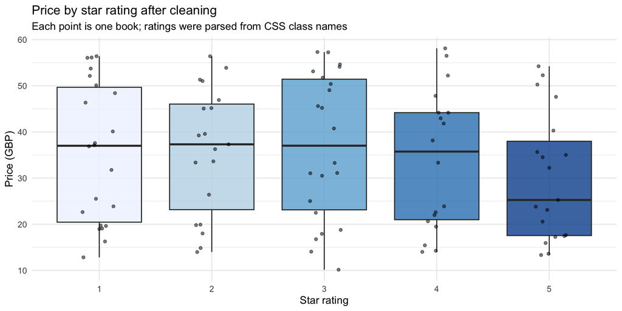

```r
ggplot(books, aes(factor(rating), price_gbp, fill = factor(rating))) +
  geom_boxplot(show.legend = FALSE, alpha = 0.8) +
  geom_jitter(width = 0.15, size = 1.2, alpha = 0.5, show.legend = FALSE) +
  scale_fill_brewer(palette = "Blues") +
  labs(title = "Price by star rating after cleaning",
       subtitle = "Each point is one book; ratings were parsed from CSS class names",
       x = "Star rating", y = "Price (GBP)") +
  theme_minimal()
```

## Export the clean dataset

```r
books_clean <- books %>%
  select(upc, title, title_was_truncated, category, category_imputed, price_gbp, price_band,
         rating, stock_count, stock_imputed, description, description_imputed,
         description_words, url, scraped_at)

write_csv(books_clean, "../data/processed/q4_books_clean.csv", na = "NA")
glimpse(books_clean)
```

```
## Rows: 100
## Columns: 15
## $ upc                 <chr> "a897fe39b1053632", "90fa61229261140a", "6957f44c3847a760", "e00eb4fd7b871a48", "4165285e1…
## $ title               <chr> "A Light in the Attic", "Tipping the Velvet", "Soumission", "Sharp Objects", "Sapiens: A B…
## $ title_was_truncated <lgl> TRUE, FALSE, FALSE, FALSE, TRUE, FALSE, TRUE, TRUE, TRUE, FALSE, TRUE, FALSE, FALSE, TRUE,…
## $ category            <chr> "Poetry", "Historical Fiction", "Fiction", "Mystery", "History", "Young Adult", "Business"…
## $ category_imputed    <lgl> FALSE, FALSE, FALSE, FALSE, FALSE, FALSE, FALSE, TRUE, TRUE, FALSE, TRUE, FALSE, FALSE, FA…
## $ price_gbp           <dbl> 51.77, 53.74, 50.10, 47.82, 54.23, 22.65, 33.34, 17.93, 22.60, 52.15, 13.99, 20.66, 17.46,…
## $ price_band          <chr> "Premium (over 40)", "Premium (over 40)", "Premium (over 40)", "Premium (over 40)", "Premi…
## $ rating              <dbl> 3, 1, 1, 4, 5, 1, 4, 3, 4, 1, 2, 4, 5, 5, 5, 3, 1, 1, 2, 2, 1, 2, 3, 5, 5, 3, 3, 3, 5, 4, …
## $ stock_count         <int> 22, 20, 20, 20, 20, 19, 19, 19, 19, 19, 19, 19, 19, 19, 19, 19, 19, 19, 19, 19, 19, 19, 19…
## $ stock_imputed       <lgl> FALSE, FALSE, FALSE, FALSE, FALSE, FALSE, FALSE, FALSE, FALSE, FALSE, FALSE, FALSE, FALSE,…
## $ description         <chr> "It's hard to imagine a world without A Light in the Attic. This now-classic collection of…
## $ description_imputed <lgl> FALSE, FALSE, FALSE, FALSE, FALSE, FALSE, FALSE, FALSE, FALSE, FALSE, FALSE, FALSE, FALSE,…
## $ description_words   <int> 103, 105, 105, 209, 246, 104, 228, 498, 273, 408, 133, 80, 68, 89, 87, 108, 191, 224, 136,…
## $ url                 <chr> "https://books.toscrape.com/catalogue/a-light-in-the-attic_1000/index.html", "https://book…
## $ scraped_at          <chr> "2026-11-12 19:48:10", "2026-11-12 19:48:10", "2026-11-12 19:48:10", "2026-11-12 19:48:10"…
```

# 4.3 Load and analyse in PostgreSQL

## Import into a relational table

The table, its constraints and the `\copy` import live in `sql/01_create_and_load.sql`. The CHECK constraints act as a final quality gate: a rating outside 1 to 5 or a negative stock count would make the import fail. The script is run with `psql`:

```r
pg <- dbConnect(Postgres(), dbname = "postgres")
if (!dbGetQuery(pg, "SELECT COUNT(*) AS n FROM pg_database WHERE datname = $1",
                params = list(params$db_name))$n) {
  invisible(dbExecute(pg, paste("CREATE DATABASE", params$db_name)))
}
dbDisconnect(pg)
```

```r
load_log <- system2("psql", c("-d", params$db_name, "-X", "-f", "sql/01_create_and_load.sql"),
                    stdout = TRUE, stderr = TRUE)
cat(load_log, sep = "\n")
```

```
DROP TABLE
CREATE TABLE
COPY 100
 rows_loaded | categories | imputed_categories | imputed_descriptions | min_price | max_price
-------------+------------+--------------------+----------------------+-----------+-----------
         100 |         28 |                 14 |                    0 |     10.16 |     58.11
(1 row)
```

```r
con <- dbConnect(Postgres(), dbname = params$db_name)
dbGetQuery(con, "SELECT column_name, data_type FROM information_schema.columns
                 WHERE table_name = 'books' ORDER BY ordinal_position")
```

| column_name | data_type |
| --- | --- |
| upc | character |
| title | text |
| title_was_truncated | boolean |
| category | text |
| category_imputed | boolean |
| price_gbp | numeric |
| price_band | text |
| rating | smallint |
| stock_count | integer |
| stock_imputed | boolean |
| description | text |
| description_imputed | boolean |
| description_words | integer |
| url | text |
| scraped_at | timestamp without time zone |

## Investigation 1: Does a better rating mean a higher price or more stock?

```sql
-- Investigation 1: do better rated books cost more or carry more stock?
-- Summarises the catalogue by star rating and adds the overall
-- correlation of rating with price and with stock.
WITH overall AS (
    SELECT ROUND(CORR(rating, price_gbp)::numeric, 3)   AS corr_rating_price,
           ROUND(CORR(rating, stock_count)::numeric, 3) AS corr_rating_stock,
           COUNT(*)                                     AS total_books
    FROM books
)
SELECT b.rating,
       COUNT(*)                                        AS books,
       ROUND(100.0 * COUNT(*) / o.total_books, 1)      AS pct_of_catalogue,
       ROUND(AVG(b.price_gbp), 2)                      AS avg_price_gbp,
       ROUND(AVG(b.stock_count), 1)                    AS avg_stock,
       SUM(b.price_gbp * b.stock_count)                AS stock_value_gbp,
       o.corr_rating_price,
       o.corr_rating_stock
FROM books b
CROSS JOIN overall o
GROUP BY b.rating, o.total_books, o.corr_rating_price, o.corr_rating_stock
ORDER BY b.rating;
```

```r
q1
```

| rating | books | pct_of_catalogue | avg_price_gbp | avg_stock | stock_value_gbp | corr_rating_price | corr_rating_stock |
| --- | --- | --- | --- | --- | --- | --- | --- |
| 1 | 22 | 22 | 35.52 | 17.2 | 13478.61 | -0.122 | 0.064 |
| 2 | 19 | 19 | 35.91 | 16.8 | 11455.99 | -0.122 | 0.064 |
| 3 | 22 | 22 | 36.84 | 17.3 | 14171.88 | -0.122 | 0.064 |
| 4 | 18 | 18 | 33.98 | 16.9 | 10400.60 | -0.122 | 0.064 |
| 5 | 19 | 19 | 30.01 | 17.5 | 10100.47 | -0.122 | 0.064 |

**Interpretation.** The ratings are spread almost evenly, with each star level holding 18% to 22% of the catalogue. Price hardly changes with rating: one star books average £35.52 while five star books average £30.01, and the correlation between rating and price is only -0.12. If anything, the best reviewed books are slightly cheaper. Stock is flat at about 17 units for every rating, with a correlation of 0.06, so the competitor does not stock up on popular titles either. For our shop this means the competitor does not use reviews when pricing. Highly rated books that we sell at a premium are therefore exposed, because shoppers can find them cheaper there. With only 100 books the correlations are weak evidence, so this should be checked again on the full catalogue of 1,000 titles.

## Investigation 2: Which categories hold the most stock value?

```sql
-- Investigation 2: which categories hold the most stock value, and what is
-- the top priced title in each? Uses window functions to rank categories
-- and to pick the most expensive book per category.
WITH ranked_books AS (
    SELECT category,
           title,
           price_gbp,
           ROW_NUMBER() OVER (PARTITION BY category ORDER BY price_gbp DESC) AS price_rank
    FROM books
),
category_summary AS (
    SELECT category,
           COUNT(*)                              AS books,
           ROUND(AVG(price_gbp), 2)              AS avg_price_gbp,
           ROUND(AVG(rating), 2)                 AS avg_rating,
           SUM(stock_count)                      AS units_in_stock,
           SUM(price_gbp * stock_count)          AS stock_value_gbp,
           SUM(category_imputed::int)            AS imputed_rows
    FROM books
    GROUP BY category
    HAVING COUNT(*) >= 3
)
SELECT RANK() OVER (ORDER BY c.stock_value_gbp DESC)                      AS value_rank,
       c.category,
       c.books,
       c.avg_price_gbp,
       c.avg_rating,
       c.units_in_stock,
       c.stock_value_gbp,
       ROUND(100.0 * c.stock_value_gbp / SUM(c.stock_value_gbp) OVER (), 1) AS pct_of_value,
       c.imputed_rows,
       r.title                                                             AS top_priced_title,
       r.price_gbp                                                         AS top_price_gbp
FROM category_summary c
JOIN ranked_books r
  ON r.category = c.category AND r.price_rank = 1
ORDER BY value_rank;
```

```r
q2
```

| value_rank | category | books | avg_price_gbp | avg_rating | units_in_stock | stock_value_gbp | pct_of_value | imputed_rows | top_priced_title | top_price_gbp |
| --- | --- | --- | --- | --- | --- | --- | --- | --- | --- | --- |
| 1 | Sequential Art | 15 | 32.42 | 2.80 | 243 | 7937.19 | 17.2 | 1 | Scott Pilgrim’s Precious Little Life (Scott Pilgrim #1) | 52.29 |
| 2 | Nonfiction | 13 | 31.82 | 3.15 | 214 | 6811.10 | 14.8 | 1 | The Electric Pencil: Drawings from Inside State Hospital No. 3 | 56.06 |
| 3 | Poetry | 7 | 36.24 | 2.57 | 129 | 4750.35 | 10.3 | 0 | Slow States of Collapse: Poems | 57.31 |
| 4 | Uncategorised | 10 | 23.60 | 2.80 | 176 | 4109.36 | 8.9 | 10 | Judo: Seven Steps to Black Belt (an Introductory Guide for Beginners) | 53.90 |
| 5 | Fiction | 5 | 43.87 | 3.80 | 85 | 3757.77 | 8.2 | 0 | The Murder That Never Was (Forensic Instincts #5) | 54.11 |
| 6 | Childrens | 4 | 50.20 | 2.00 | 72 | 3609.73 | 7.8 | 1 | The Secret of Dreadwillow Carse | 56.13 |
| 7 | Food and Drink | 5 | 34.89 | 2.20 | 83 | 2882.44 | 6.3 | 0 | The Pioneer Woman Cooks: Dinnertime: Comfort Classics, Freezer Food, 16-Minute Meals, and Other Delicious Ways to Solve Supper! | 56.41 |
| 8 | Music | 3 | 43.20 | 3.33 | 57 | 2462.21 | 5.3 | 0 | Our Band Could Be Your Life: Scenes from the American Indie Underground, 1981-1991 | 57.25 |
| 9 | History | 4 | 33.94 | 2.25 | 68 | 2389.08 | 5.2 | 0 | Sapiens: A Brief History of Humankind | 54.23 |
| 10 | Mystery | 3 | 41.32 | 3.00 | 54 | 2213.74 | 4.8 | 0 | The Past Never Ends | 56.50 |
| 11 | Fantasy | 4 | 28.39 | 3.25 | 64 | 1816.64 | 3.9 | 0 | Masks and Shadows | 56.40 |
| 12 | Young Adult | 4 | 25.05 | 2.75 | 70 | 1723.37 | 3.7 | 0 | The Natural History of Us (The Fine Art of Pretending #2) | 45.22 |
| 13 | Thriller | 3 | 29.63 | 3.33 | 55 | 1612.68 | 3.5 | 0 | Behind Closed Doors | 52.22 |

**Interpretation.** Sequential Art (graphic novels) and Nonfiction are the two most valuable categories and together hold about 32% of the stock value among categories with at least three titles. Their lead comes from the number of titles they carry, not from price: their average prices (£32.42 and £31.82) are below Fiction (£43.87) and Childrens (£50.20). Childrens books are the most expensive group but also the worst rated (average 2.0 stars), which looks like a pricing weakness. Fiction combines a high price with the best average rating (3.8), so it is the competitor’s strongest category. The “Uncategorised” group, which exists only because of missing source data, still ranks fourth with almost 9% of stock value. This shows that poor category data would hide a real share of the catalogue from category level reporting, which is why the imputation flags matter.

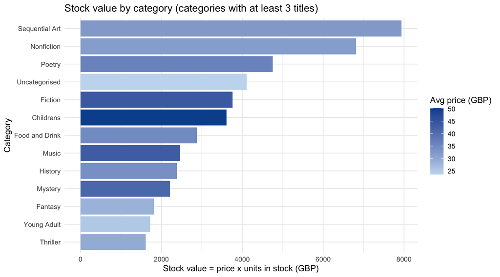

```r
q2 %>%
  mutate(category = reorder(category, stock_value_gbp)) %>%
  ggplot(aes(stock_value_gbp, category, fill = avg_price_gbp)) +
  geom_col() +
  scale_fill_gradient(low = "#C6DBEF", high = "#08519C", name = "Avg price (GBP)") +
  labs(title = "Stock value by category (categories with at least 3 titles)",
       x = "Stock value = price x units in stock (GBP)", y = "Category") +
  theme_minimal()
```